# Modeling and Visualizing In-Game Win Probability in NCAA Men’s Basketball

### Cooper Olney

##### Department of Math, Computer Science, and Statistics St. Lawrence University Advised by Dr. Matt Higham

# Abstract

- Built and compared multiple statistical models to estimate in-game win probability for NCAA men’s basketball.
- Visualized how the home team’s win probability changes throughout a game using dynamic probability plots.
- Designed an interactive data storytelling experience with Quarto Closeread to showcase model performance and key game moments.

# Data

2025 NCAA men’s basketball play-by-play data was collected using the `hoopR` package. Ratings data sourced from TeamRankings.

Predictor variables used in the models included:

- **Time Elapsed** - seconds played in the game.
- **Score Differential** - point margin between teams (home - away).
- **Rating Differential** - difference in team ratings (home - away).

The final training dataset contained:

- 6,136 games & 14,732,536 play-by-play observations.

# Logistic Regression Models

- Frequentist and Bayesian logistic regression models were developed to estimate win probability from game state variables and team strength.

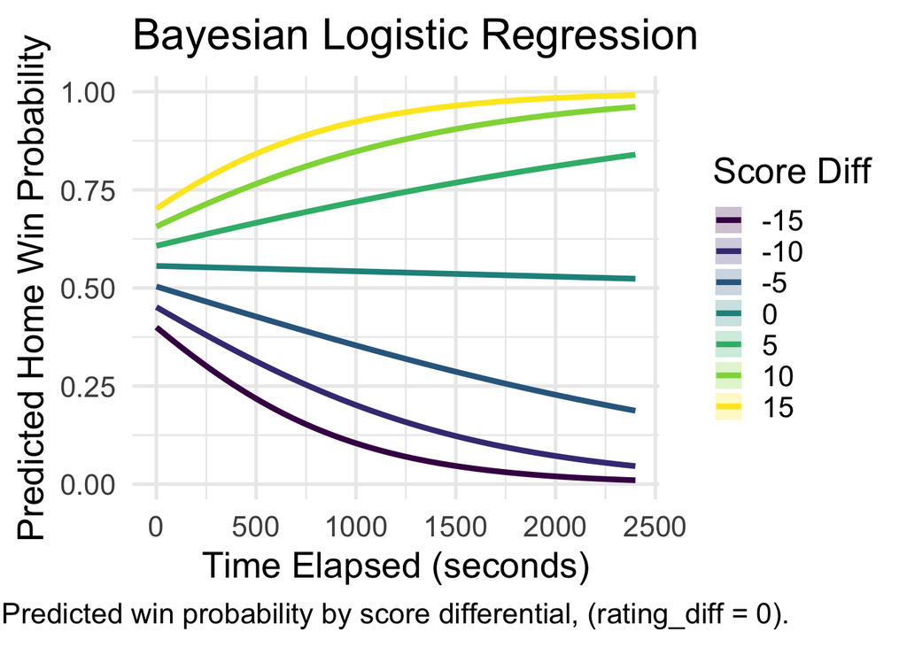

- Early in games, team strength and home-court effects influence win probability. As time expires, score differential becomes the dominant predictor of the game’s outcome.

# Dynamic Bayesian Model

- Estimates win probability directly from historical game outcomes rather than fitting a regression model.
- For each combination of `time_elapsed` and `score_diff`, the model uses previous games to estimate the probability of the home team winning.

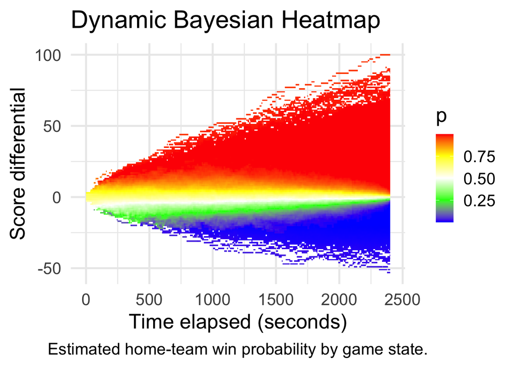

- Score differential becomes increasingly important as time expires, with large late-game leads corresponding to win probabilities near 0% or 100%.
- A Beta prior smooths estimates in regions with limited historical observations, reducing extreme probabilities caused by sparse data.

# Predicted Probability Plots

- The trained models can be applied to individual games to visualize how win probability changes second-by-second.

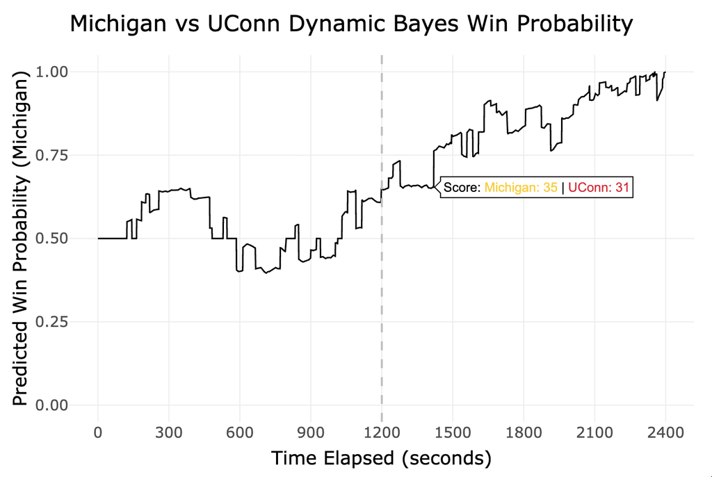

- The plot captures how momentum shifts throughout a game, highlighting key moments and turning points.
- Win probability begins at exactly 50% because the Dynamic Bayes model depends only on game state and it was played at a neutral site.

# Closeread

- Quarto Closeread was used to create an interactive “scrollytelling” experience that guides readers through the key moments of March Madness and the 2026 National Championship game.

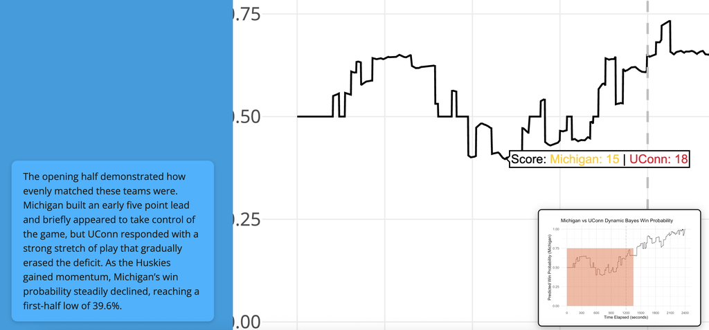

- Closeread synchronizes narrative text and visualizations as readers scroll through a document. Advancing through the document can trigger plots to zoom, pan, or transition to new views.
- Custom CSS styling was used to enhance the presentation, including a picture-in-picture feature that appears only when a plot is zoomed.

# Conclusions

- In-game win probability models reveal how team strength, score differential, and time remaining combine to influence a team’s chances of winning.
- **Future Directions** - Train model on multiple seasons of data, compare and validate the training models, and incorporate additional games state variables.

# References & Acknowledgements

- Johnson, A. A., Ott, M. Q., & Dogucu, M. (2022). Bayes rules! An introduction to applied Bayesian modeling.
- Maddox, J., Sides R., & Harvill L. J. (2022). Bayesian estimation of in-game home team win probability for college basketball.
- Taylor, J. A. (2025). A Bayesian logistic regression framework for in-game win probability estimation in NCAA basketball.